# Pruning & Rooting Phylogenetic Tree with ggTree for snail microbiome study

# 5. Root the Tree

## 5b. Midpoint Root

Root the tree to the midpoint since there are no archaea in the samples

```r
# Check to see if tree is rooted.. expect it to be false
is.rooted(phy_tree(unrooted_physeq_rm_euk_arch)) ##false
```

```
## [1] FALSE
```

```r
# Let's midpoint root the tree
midpoint_rooted_tree <-
  unrooted_physeq_rm_euk_arch %>%
  phy_tree() %>%
  phytools::midpoint.root()

# Is the new tree rooted? Should be TRUE!
is.rooted(midpoint_rooted_tree)
```

```
## [1] TRUE
```

```r
# Assign to a new phyloseq object!
# Merge tree with the raw_preprocessed physeq
midpoint_rooted_physeq <-
  merge_phyloseq(raw_preprocessed_physeq, midpoint_rooted_tree)
```

### Plot Midpoint Rooted Tree

Plot the midpoint rooted tree to ensure that no eukarya or long branches are present

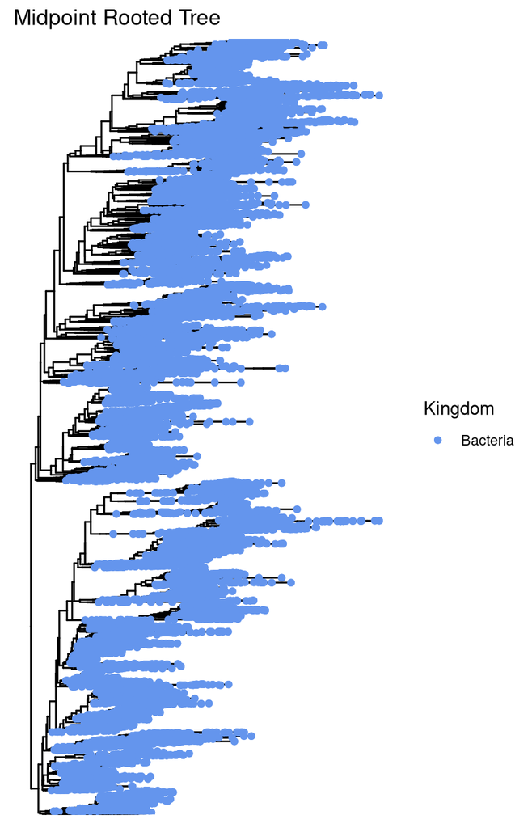

```r
# Quick inspection of tree
midpoint_rooted_tree_plot <-
  ggtree(midpoint_rooted_physeq) +
  geom_tippoint(mapping = aes(color = Kingdom)) +
  geom_tippoint(aes(color = Kingdom)) +
  labs(title = "Midpoint Rooted Tree") +
  scale_color_manual(values = c("cornflowerblue", "firebrick3", "grey"))

# Look at the tree
midpoint_rooted_tree_plot
```

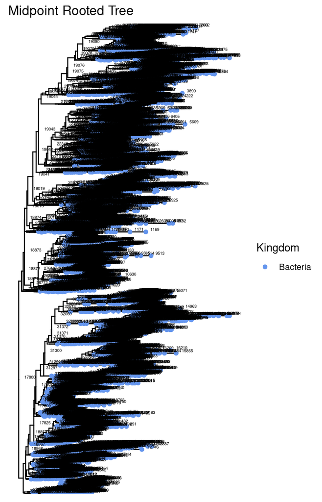

```r
# Add nodes
midpoint_rooted_tree_node_plot <-
  midpoint_rooted_tree_plot +
  geom_text(aes(label = node), hjust = -0.5, vjust = -0.3, size = 1.5)

# View it
midpoint_rooted_tree_node_plot
```

INTERPRETATION #3 (If midpoint rooting): Now that you’ve rooted your tree, does the tree seem “finalized”? Are there any other branches/ASVs to inspect? Why or why not?

I think the three seems finalized. There are no extremely long branches when rooted at the midpoint. The tree is split into two big clusters, but even at the base, none of the branches are too long. There are no final branches to inspect.

# 7. Save phyloseq objects

The phyloseq objects can be saved in one file as a list of objects. Or, we can save them individually. Two examples are below:

### Save multiple phyloseq objects as a list

```r
# Take a quick look
midpoint_rooted_physeq # Midpiont rooted tree
```

```
## phyloseq-class experiment-level object
## otu_table()   OTU Table:         [ 17799 taxa and 60 samples ]
## sample_data() Sample Data:       [ 60 samples by 38 sample variables ]
## tax_table()   Taxonomy Table:    [ 17799 taxa by 9 taxonomic ranks ]
## phy_tree()    Phylogenetic Tree: [ 17799 tips and 17798 internal nodes ]
```

```r
# Save both phyloseq objects to one .RData file
save(list = c("midpoint_rooted_physeq"),
     file = "data/04_PhylogeneticTree/phytree_preprocessed_physeqs.RData")
```

### Save individual phyloseq objects

```r
# Now, save midpoint rooted phyloseq object
save(midpoint_rooted_physeq,
     file = "data/04_PhylogeneticTree/midpoint_rooted_physeq.RData")
```

Now that we have our rooted trees inside of a phyloseq object, we can go forth and begin our next analysis!

# Final info for Reproducibility

## Check Render Time

```r
# Take the time now that we are at the end of the script
end_time <- Sys.time()
end_time
```

```
## [1] "2025-05-02 01:03:13 EDT"
```

```r
# Echo the elapsed time
elapsed_time <- round((end_time - start_time), 3)
elapsed_time
```

```
## Time difference of 2.61 mins
```